# Betterland: A Responsive Web-Native Scientific Poster Extension for Quarto

Firmin Cecillon<sup>1</sup> (cecillon@rptu.de · [@fircec](https://github.com/fircec))

<sup>1</sup> Applied Machine Learning, Fachbereich Informatik, RPTU Kaiserslautern, Deutschland

**Betterland** makes web-native scientific posters from plain Markdown — readable on **any screen**, printable to **A0**, no HTML required.

## Motivation

Academic posters are among the most common formats for sharing research, yet most fail basic graphic design principles — even award-winning posters are structured like journal articles rather than visual communication (Faulkes, 2023). Worse, they are distributed as PDFs: fixed-size files that require zooming on screens, are inaccessible to screen readers, and cannot reflow to different display contexts.

## The Better Poster Concept

Morrison (2019) proposed a three-column landscape layout with the main finding in the centre, methods on the left, and figures on the right. Empirical evidence supports this: Bentsen & Østergaard (2026) found significant advantages for the Better Poster format in first impression (*p* = 1.64 × 10<sup>−6</sup>) across 103 posters at a real scientific conference.

## Methods

Betterland is a Quarto extension with five components:

1. **`_extension.yml`** — format declaration, disables Bootstrap
2. **`template.html`** — semantic HTML5 skeleton (`<header>`, `<main>`, `<aside>`)
3. **`poster.lua`** — ~230 line Lua filter, populates five template slots
4. **`poster.css`** — CSS Grid (`1fr 3fr 1fr`), fluid `clamp()` typography, responsive reflow below 1024px
5. **`poster-print.css`** — A0 typography and `@page { size: A0 landscape }`

## Key Design Decisions

- **Full methods retained** in left column — informed by Oronje et al. (2024), who found billboard-poster viewers wanted more methodological detail
- **Semantic HTML5** throughout — following WCAG 2.2 (W3C, 2023), making output more accessible than PDF by default
- **Breakpoint at 1024px** — boundary between tablet landscape (three-column viable) and portrait (not viable)

## Authoring Experience

The entire poster is written in Markdown and YAML — no HTML or CSS required. Content goes into two named zones:

```markdown
::: {.poster-left}
## Methods
## Results
:::

::: {.poster-right}
## Figures
## References
:::
```

## Feature Comparison

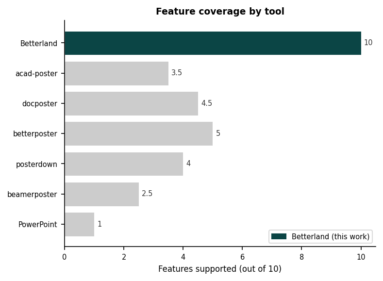

## Responsive Layout

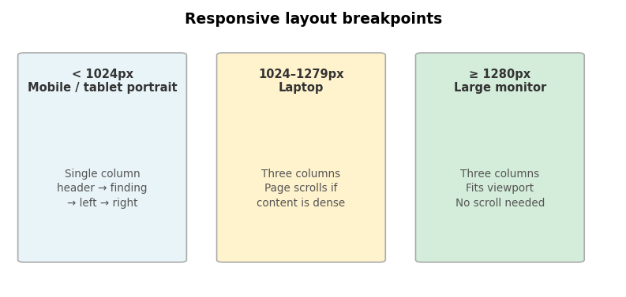

## Evaluation

| Goal | Description | Status |
| --- | --- | --- |
| G1 | Morrison layout as Quarto extension | ✓ |
| G2 | Literate programming R and Python | ✓ |
| G3 | Design grounded in literature | Partial |
| G4 | Simple YAML and Markdown authoring | ✓ |
| G5 | Responsive across screen sizes | Partial |
| G6 | Printable to A0 landscape | ✓ |
| G7 | More accessible than PDF | Partial |
| G8 | Self-referential demonstration poster | ✓ |

## References

Bentsen & Østergaard (2026). *J. Cancer Education*, 41, 49–54. [doi:10.1007/s13187-025-02622-1](https://doi.org/10.1007/s13187-025-02622-1)

Faulkes (2021). *Better Posters*. Pelagic Publishing.

Faulkes (2023). *Frontiers in Communication*, 8, 1063345. [doi:10.3389/fcomm.2023.1063345](https://doi.org/10.3389/fcomm.2023.1063345)

Morrison (2019). *Better Scientific Poster*. OSF. [osf.io/ef53g](https://osf.io/ef53g/)

Oronje, Morrison et al. (2024). *Qeios* (preprint). [doi:10.32388/p7n5bo.2](https://doi.org/10.32388/p7n5bo.2)

W3C WAI (2023). *WCAG 2.2*. [w3.org/TR/WCAG22](https://www.w3.org/TR/WCAG22/)